# Effect of epidemiological variation on dynamics

I am struggling to understand the results when there is covariation among epidemiological parameters. One thing that might be worth checking is whether variation (not covariation) has any effect, since I’m not sure that’s been done systematically. I will allow different degrees of variation and compare the numerical results against the analytical expectations for $R_0$ and $S_e$ to see if one or the other seems to agree more closely.

Let’s start with variation in contact rate only. According to our analytical results, the effects of variation in contact on $R_0$ and $S_e$ can be summarized as:
$$\begin{align}
E[R_0(c)] &= R_0(\bar{c}), \\
E[S_e(c)] &= S_e(\hat{c}) \left(1 + \frac{1}{\hat{c}^2} \sigma_c^2\right).
\end{align}$$
Note that with our choices of variation ($\sigma_c = \hat{c}/2$, $\sigma_c=\hat{c}$, and $\sigma_c = 2 \hat{c}$), the expected susceptible population size will be 1.25, 2, and 5 times as large as in the no variation case.

Comparing against the numerical results.

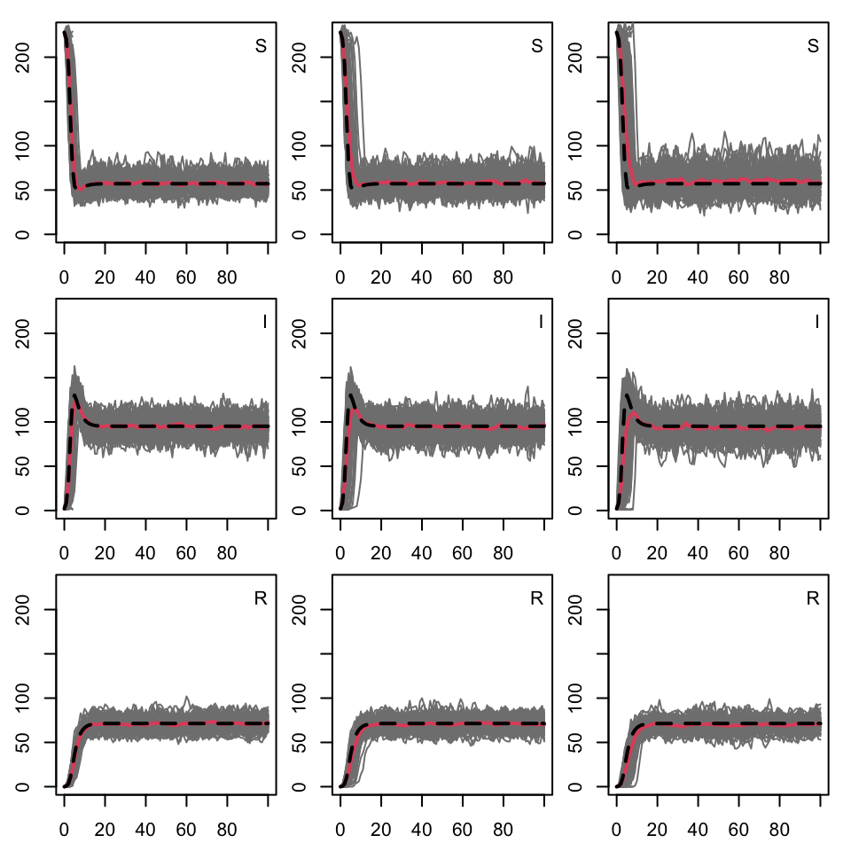

Effect of variation in contact rate on the dynamics of susceptible, infected, and recovered hosts. By column, we move from low to moderate to high variation. The dashed black line shows the deterministic expectation.

According to our analytical results, the effects of variation in shedding on $R_0$ and $S_e$ can be summarized as:
$$\begin{align}
E[R_0(s)] &= R_0\left(\bar{s}\right)\left(1-\frac{h}{\bar{s}\left(h+\bar{s}\right)^2}\sigma_s^2\right), \\
E[S_e(s)] &= S_e(\hat{s}) \left(1 + \frac{h}{\hat{s}^2(h+\hat{s})} \sigma_s^2\right).
\end{align}$$
Based on this, we expect variation in shedding to decrease $R_0$, and to increase $S_e$.

[figure not shown]

Effect of variation in shedding rate on the dynamics of susceptible, infected, and recovered hosts. By column, we move from low to moderate to high variation. The dashed black line shows the deterministic expectation.

According to our analytical results, the effects of variation in virulence on $R_0$ and $S_e$ can be summarized as:
$$\begin{align}
E[R_0(\alpha)] &= R_0\left(\bar{\alpha}\right)\left(1 + \frac{\sigma_\alpha^2}{\left(\bar{\alpha}+\gamma+d\right)^2}\right), \\
E[S_e(\alpha)] &= S_e(\hat{\alpha}).
\end{align}$$
Based on this, variation in virulence is expected to increase $R_0$ but have no effect on the number of susceptible hosts at equilibrium.

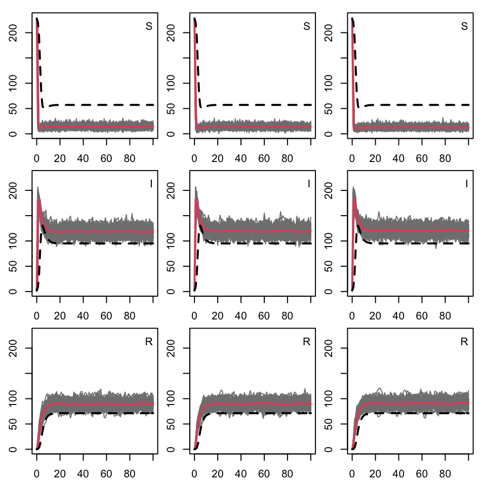

Effect of variation in virulence on the dynamics of susceptible, infected, and recovered hosts. By column, we move from low to moderate to high variation. The dashed black line shows the deterministic expectation.

Again we see discrepancies between the expectation and the numerical results. I can’t shake the idea that this might be because we are using a lognormal distribution, rather than a symmetric normal. I worry that interacts with the nonlinearity of the model. To determine if that is the case, I have rewritten the functions to allow normally distributed traits. I have to truncate these distributions, of course, to prevent negative values, but this is fairly rare.

#### Assuming normally distributed traits

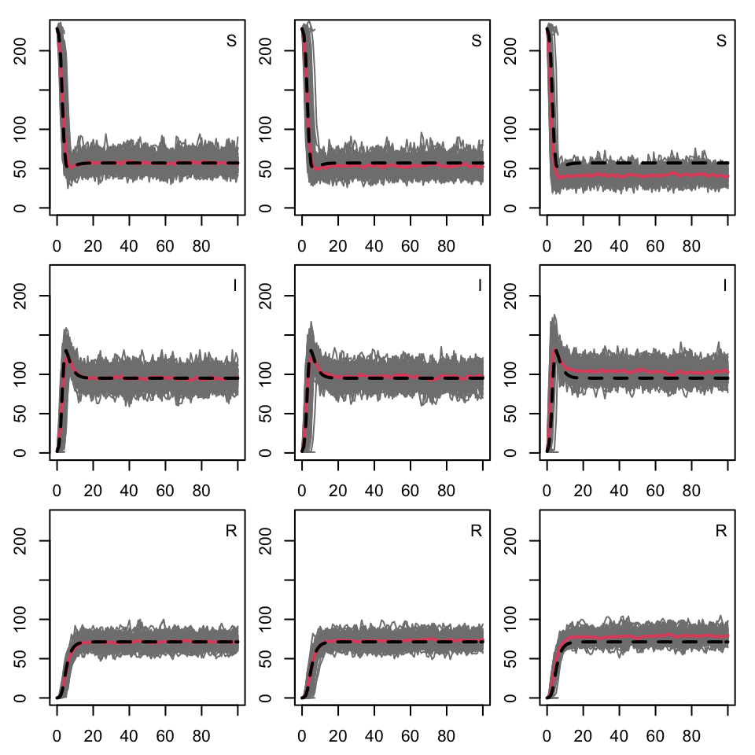

Effect of variation in contact rate on the dynamics of susceptible, infected, and recovered hosts when the trait distributions are normal, rather than lognormal. By column, we move from low to moderate to high variation. The dashed black line shows the deterministic expectation.

According to our analytical results, the effects of variation in shedding on $R_0$ and $S_e$ can be summarized as:
$$\begin{align}
E[R_0(s)] &= R_0\left(\bar{s}\right)\left(1-\frac{h}{\bar{s}\left(h+\bar{s}\right)^2}\sigma_s^2\right), \\
E[S_e(s)] &= S_e(\hat{s}) \left(1 + \frac{h}{\hat{s}^2(h+\hat{s})} \sigma_s^2\right).
\end{align}$$
Based on this, we expect variation in shedding to decrease $R_0$, and to increase $S_e$.

[figure not shown]

Effect of variation in shedding rate on the dynamics of susceptible, infected, and recovered hosts. By column, we move from low to moderate to high variation. The dashed black line shows the deterministic expectation.

According to our analytical results, the effects of variation in virulence on $R_0$ and $S_e$ can be summarized as:
$$\begin{align}
E[R_0(\alpha)] &= R_0\left(\bar{\alpha}\right)\left(1 + \frac{\sigma_\alpha^2}{\left(\bar{\alpha}+\gamma+d\right)^2}\right), \\
E[S_e(\alpha)] &= S_e(\hat{\alpha}).
\end{align}$$
Based on this, variation in virulence is expected to increase $R_0$ but have no effect on the number of susceptible hosts at equilibrium.

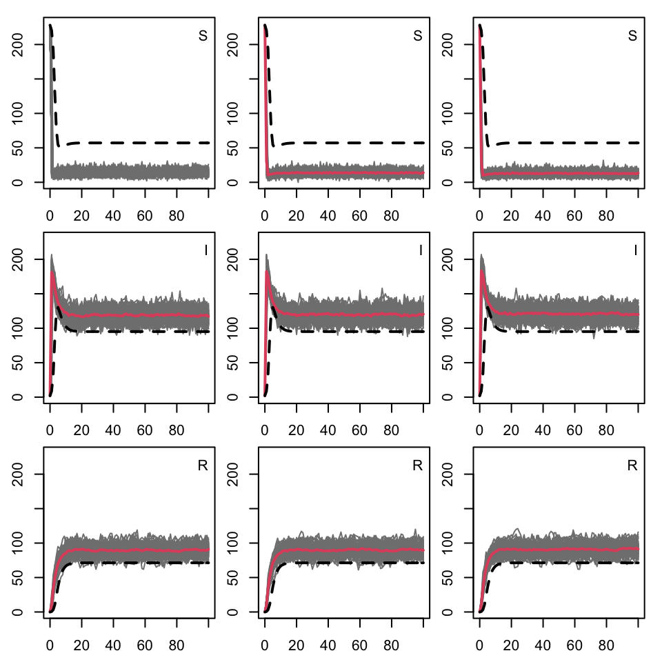

Effect of variation in virulence on the dynamics of susceptible, infected, and recovered hosts. By column, we move from low to moderate to high variation. The dashed black line shows the deterministic expectation.